# Reef exercise: worked solution

PCB 6455 / BSC 4933: Biometry | Lecture 14

Dr. Brian Maitner

## How to use this

One possible answer to the reef exercise, with the code filled in.

**Your answers will differ**, and that is fine. Two places where a different choice is just as defensible are flagged as we go.

What matters is that each decision was made for a reason you could state.

## Setting up

```r
reef <- read.csv("https://github.com/bmaitner/biometry_course/raw/refs/heads/main/data/Reef_fish/NCRMP_reef_fish_surveys.csv")

reef$protected <- ifelse(reef$PROT == 0, "no", "yes")

# 8 of 8560 surveys recorded no fish, and log(0) is -Inf
reef <- reef[reef$total_abundance > 0, ]

unprot <- reef$total_abundance[reef$protected == "no"]
prot   <- reef$total_abundance[reef$protected == "yes"]

c(unprotected = length(unprot), protected = length(prot))
```

```
unprotected   protected
       5151        3401
```

## 1. The deterministic part

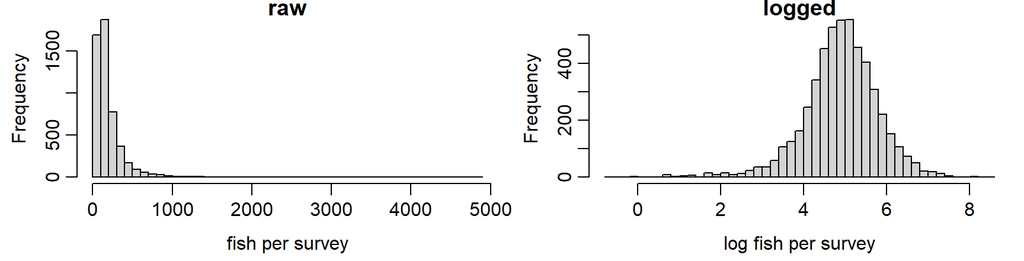

```r
par(mfrow = c(1, 2))
hist(unprot, breaks = 40, main = "raw", xlab = "fish per survey")
hist(log(unprot), breaks = 40, main = "logged", xlab = "log fish per survey")
```

Raw is strongly right skewed, logged is near symmetric. So describe the effect as a **ratio**, not a difference.

```r
c(median_unprot = median(unprot), median_prot = median(prot),
  ratio = median(prot) / median(unprot))
```

```
median_unprot   median_prot         ratio
   139.220000    170.960000      1.227984
```

## 2. The distribution

Positive, continuous, right skewed, symmetric once logged: **lognormal**. Gamma would also have been defensible.

The check, on something we did not fit:

```r
mean(unprot > 500)                                     # observed
```

```
[1] 0.05513493
```

```r
plnorm(500, meanlog = mean(log(unprot)),
       sdlog = sd(log(unprot)), lower.tail = FALSE)    # predicted
```

```
[1] 0.07102824
```

Same ballpark. The lognormal slightly **over-predicts** very rich surveys, which is worth noticing rather than hiding.

## 3. The parameters

```r
meanlog_unprot <- mean(log(unprot))
sdlog_unprot   <- sd(log(unprot))

meanlog_prot <- mean(log(prot))
sdlog_prot   <- sd(log(prot))

round(c(meanlog_unprot = meanlog_unprot, sdlog_unprot = sdlog_unprot,
        meanlog_prot = meanlog_prot, sdlog_prot = sdlog_prot), 2)
```

```
meanlog_unprot   sdlog_unprot   meanlog_prot     sdlog_prot
          4.90           0.90           5.17           0.91
```

The two spreads are nearly identical, so one spread can be used for both groups.

`meanlog` is about 5 because `exp(5)` is about 150 fish. If yours was near 150, you handed `rlnorm()` a raw mean.

## 4. The choices

```r
n_per_group <- 60      # 120 surveys, split evenly
effect <- 1.5          # detect a 50% difference
```

Neither of these came from the data. The budget is the agency’s, and the effect size is a judgement about what difference would matter.

## 5. Simulate, analyze, repeat

```r
power_reef <- function(n_per_group, effect, nsim = 500,
                       meanlog = meanlog_unprot, sdlog = sdlog_unprot) {

  found <- numeric(nsim)

  for (i in 1:nsim) {

    sim_unprot <- rlnorm(n_per_group, meanlog = meanlog, sdlog = sdlog)
    sim_prot   <- rlnorm(n_per_group, meanlog = meanlog + log(effect),
                         sdlog = sdlog)

    found[i] <- t.test(log(sim_unprot), log(sim_prot))$p.value < 0.05

  }

  mean(found)

}

power_reef(n_per_group = 60, effect = 1.5)
```

```
[1] 0.7
```

## How many surveys do you need?

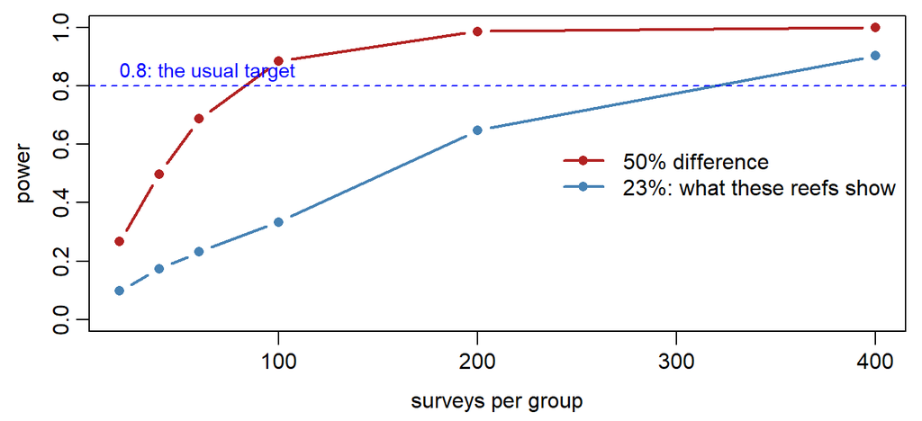

| surveys_per_group | power_50pct | power_23pct |
| --- | --- | --- |
| 20 | 0.27 | 0.10 |
| 40 | 0.50 | 0.17 |
| 60 | 0.69 | 0.23 |
| 100 | 0.88 | 0.33 |
| 200 | 0.99 | 0.65 |
| 400 | 1.00 | 0.90 |

## What this tells the manager

- A **50% difference** is detectable with roughly **80 to 100 surveys per group**.
- The difference these reefs actually show, about **23%**, needs roughly **400 per group**.
- With the 120 surveys on offer, split evenly, power for the real difference is around **0.2**.

So: protection may well work, and this survey could not show it. **Failing to detect is not evidence of no effect.**